```python
# setting up jupyter
%matplotlib inline
import matplotlib as mpl
mpl.rcParams['figure.dpi'] = 300
mpl.rcParams['savefig.dpi'] = 300
```

# Example 1: successive differentiation of hESCs to hepatocytes

In this experiment human embryonic stem cells were treated with a selection of stimuli to differentiate into hepatocytes/ liver tissue. Within the a period of 3 weeks, 10 samples were taken and sequenced on different days. This example goes into samples and targets initiation and basic plotting.

## Initializing samples and targets

To **initiate the samples instance**, we pass a TSV expression file and gene list data. Since there are no replicates in this data, we cannot identify significant differential genes with DESeq2 (of which DPre accepts the output). Instead, in this analysis, differential genes were defined as those with a differential Z-score >2; <-2. Since this is not to uncommon, DPre implements the function *add_diff_genes_from_z()* to add differential genes based on Z-scores. Additionally, we pass the name of the control to the *ctrl* argument to later plot differential effects. We also set a *name* that will appear in logs and plot annotations.

```python
import DPre
s = DPre.samples(expression = 'hsliver_expression.tsv',     # expression input data
                 diff_genes = None,    # differential gene are loaded in the next step
                 ctrl = 'Day00',     # name of the control in the data
                 name = 'in vitro hepatic differentiated hESCs'    # name of the samples instance
)
DPre.add_diff_genes_from_z(s)
```

```
INFO-DPre _log_init:
=|=|=|=|=|=|=|=|====INITIATION====|=|=|=|=|=|=|=|=|=
New samples-instance created: `in vitro hepatic differentiated hESCs`
	samples (10):
		Day00,
		Day01,
		Day02,
		Day03,
		Day05,
		Day07,
		Day09,
		Day11,
		Day13,
		Day21
	Detected genes: 12125
	Differential genes loaded: False
	Expression data loaded: True
	Control passed: Day00



INFO-DPre add_diff_genes_from_z:
Differential genes were added to the sample. Number of marker genes:
       down   up
Day00     0    0
Day01    30   50
Day02    44  119
Day03    56  168
Day05   141  263
Day07   224  400
Day09   226  479
Day11   246  489
Day13   279  505
Day21   425  554

=|=|= samples-instance =|=|=
name = in vitro hepatic differentiated hESCs;
elements = ['Day00', 'Day01', 'Day02', 'Day03', 'Day05', 'Day07', 'Day09', 'Day11', 'Day13', 'Day21'];
n = 10;
diff. genes data = True;
expression data = True;
```

The **targets initiation** is easy because we want to compare against the pre-packaged human reference data. This can simply be realized by calling the *preset_targets()* function with 'human'.

```python
from DPre import preset_targets
t = preset_targets('human')     # initiate one of the pre-packaged targets, here the human reference
```

```
INFO-DPre preset_targets:
Default targets `human` created, name: `human FANTOM5 library`, elements: 301



INFO-DPre plot_color_legend:
Color legend generated and saved at C:\Users\LOaLoA\Anaconda3\Lib\DPre\examples\example1_hsliver/human_color_legend.pdf
```

Because we did not set the *preset_colors* argument to *None*, targets default colors were set according to the respective domain. In addition, a color legend is created to reference the mapping of domains and colors.

The **command line interface** combines targets and samples initiation with producing the plot. Unlike the Python interface, the command line interface cannot infer the differential genes from Z-scores. Here, we used the *samples._diff* DataFrame to read out the differential genes and wrote them into two directories.  
Without the plot defined, the command is invalid. But for demonstration purposes the equivalent would be:

```python
!python ../../dpre.py --preset_targets "human" --samples_expression "hsliver_expression.tsv" --samples_diff_genes "./up_genelists" --samples_diff_genes "./down_genelists" --control "Day00"  --samples_name "in vitro hepatic differentiated hESCs"
```

or with abbriviated arguments:

```python
!python ../../dpre.py -pt "human" -se "hsliver_expression.tsv" -sd "./up_genelists" -sd "./down_genelists" -c "Day00"  -sn "in vitro hepatic differentiated hESCs"
```

Now that both the targets and samples are defined, we can **compute and plot the transcriptional similarity** between the two.

## Plotting target transcriptional similarity

First, we want to get an initial overview of the data. To produce this overview, the **target similarity heatmap** is called from the targets instance. Here we first want to check the **'intersect' metric**. Before that, we will change the names to something more readable. Note: in the following plot calls we pass the argument plt_show = True. This is simply for displaying the plot in jupyter and will default to False.

```python
s.names = ['Day 0', 'Day 1', 'Day 2', 'Day 3', 'Day 5', 'Day 7', 'Day 9', 'Day 11', 'Day 13', 'Day 21']
```

```
INFO-DPre names:
Ensure previous and passed names align:
  current names:  passed names:
0           Day00          Day 0
1           Day01          Day 1
2           Day02          Day 2
3           Day03          Day 3
4           Day05          Day 5
5           Day07          Day 7
6           Day09          Day 9
7           Day11         Day 11
8           Day13         Day 13
9           Day21         Day 21

INFO-DPre names:
`in vitro hepatic differentiated hESCs` renamed. New names:
['Day 0', 'Day 1', 'Day 2', 'Day 3', 'Day 5', 'Day 7', 'Day 9', 'Day 11', 'Day 13', 'Day 21']
```

```
=|=|=|=|=|=|=|=|====PLOT====|=|=|=|=|=|=|=|=|=
INFO-DPre target_similarity_heatmap:
Plot: human FANTOM5 library & in vitro hepatic differentiated hESCs

INFO-DPre _check_args:
Arguments passed. Getting data now ...

INFO-DPre plot_detec_mgs_prop:
Detection of targets (human FANTOM5 library) marker genes in samples data (in vitro hepatic differentiated hESCs):
                                              n marker genes  detected in samples  proportion
up Blood adult                                           858                  413    0.481352
   Peripheral blood mononuclear cells                    967                  472    0.488108
   Cd8+ t cells                                          891                  435    0.488215
   Eosinophils                                           934                  469    0.502141
   Cd4+cd25+cd45ra+ naive regulatory t cells             782                  401    0.512788
   Cd4+ t cells                                          805                  415    0.515528
   Natural killer cells                                  829                  428    0.516285
   Memory conventional t cells                           866                  448    0.517321
   Neutrophils                                           834                  432    0.517986
   Basophils                                             865                  449    0.519075
   Ciliary epithelial cells                              405                  344    0.849383
   Melanocyte light                                      170                  145    0.852941
   Meningeal cells                                       359                  307    0.855153
   Iris pigment epithelial cells                         292                  250    0.856164
   Melanocyte                                            237                  203    0.856540
   Smooth muscle cells intestinal                        355                  306    0.861972
   H9 embryonic stem cells                               442                  381    0.861991
   Hips +ccl2                                            428                  369    0.862150
   Astrocyte cerebral cortex                             421                  363    0.862233
   Retinal pigment epithelial cells                      280                  249    0.889286
Shown are the 20 edge proportion values.

INFO-DPre _compute_similarity:
Computing similarity `intersect` of samples `in vitro hepatic differentiated hESCs` and targets: `human FANTOM5 library` ...
INFO-DPre _get_similarity:
Selecting and processing overlap data...

INFO-DPre target_similarity_heatmap:
Drawing...
```

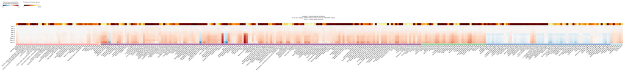

```python
hm = t.target_similarity_heatmap(samples = s,     # the samples to check similarity for
                                 metric = 'intersect',     # the metric to use for computing similarity
                                 filename = None,     # don't save this initial plot
                                 plt_show = True      # show plot in jupyter
                                )
```

The log shows normal proportions of detected marker genes in the samples. No targets are dropped for the analysis. As we can see, the default parameters of the target similarity heatmap are set to show the target labels. The plot is created with the space necessary to cleanly display all target labels. Therefore, when comparing against a large reference the plot widely extends in x-direction. Although this can be useful for reading out the similarities of all targets by zooming in, we cannot present it in this size. To solve this, we pass **heatmap_width**, *targetlabels_space*, and *specifc_target_labels* to only print the labels we care about.

```
=|=|=|=|=|=|=|=|====PLOT====|=|=|=|=|=|=|=|=|=
INFO-DPre target_similarity_heatmap:
Plot: human FANTOM5 library & in vitro hepatic differentiated hESCs

INFO-DPre _check_args:
Arguments passed. Getting data now ...
INFO-DPre _get_similarity:
Selecting and processing overlap data...

INFO-DPre target_similarity_heatmap:
Drawing...
```

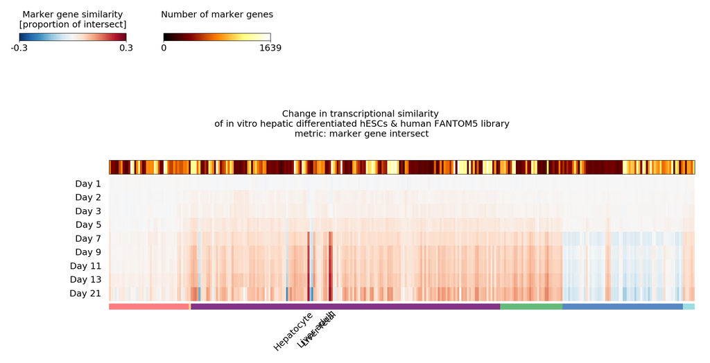

```
INFO-DPre target_similarity_heatmap:
Plot saved at C:\Users\LOaLoA\Anaconda3\Lib\DPre\examples\example1_hsliver/target_similarity_hm.pdf
```

```python
hm = t.target_similarity_heatmap(samples = s,
                                 metric = 'intersect',
                                 heatmap_width = .14,
                                 specific_target_labels = ['Hepatocyte', 'Liver adult', 'Liver fetal'],       # only print a specifc target label instead of all
                                 targetlabels_space = .1,     # size in inches under the heatmap
#                                  filename = None,
                                 plt_show = True
                                )
```

To further reduce the plot to the essentials, we pass *hide_distance_bar* (number of marker genes), *samplelabels_space* and set *title* to *None*. Also, we pass *cluster_targets* and *hide_targets_dendrogram* to emphasize peak values. We can also save the plot with the default filename now by not setting **filename** to None.

```
=|=|=|=|=|=|=|=|====PLOT====|=|=|=|=|=|=|=|=|=
INFO-DPre target_similarity_heatmap:
Plot: human FANTOM5 library & in vitro hepatic differentiated hESCs

INFO-DPre _check_args:
Arguments passed. Getting data now ...
INFO-DPre _get_similarity:
Selecting and processing overlap data...

INFO-DPre target_similarity_heatmap:
Drawing...
```

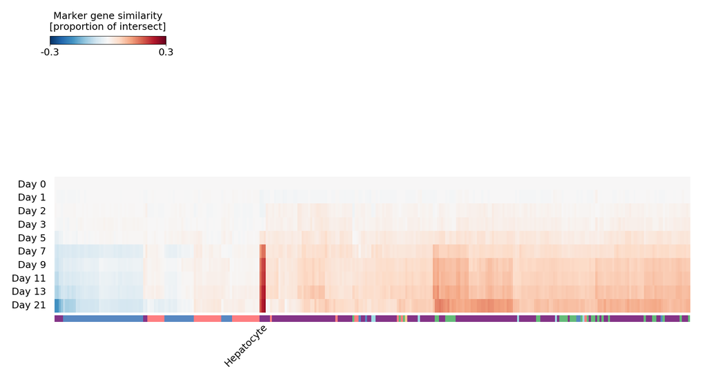

```
INFO-DPre target_similarity_heatmap:
Plot saved at C:\Users\LOaLoA\Anaconda3\Lib\DPre\examples\example1_hsliver/target_similarity_hm.pdf
```

```python
hm = t.target_similarity_heatmap(samples = s,
                                 metric = 'intersect',
                                 heatmap_width = .14,
                                 specific_target_labels = ['Hepatocyte'],
                                 targetlabels_space = .1,
                                 hide_distance_bar = True,      # hide the distance bar, for intersect n marker genes
                                 cluster_targets = True,          # emphasize peak samples and targets
                                 hide_targets_dendrogram = True,  # don't show the dendrogram to save space
                                 samplelabels_space = .3,       # save some space on the left
                                 title = None,                  # remove the title to increase clarity
#                                  filename = None,             # when not passed the default filename is used
                                 plt_show=True
                                )
```

```python
!python ../../dpre.py -pt "human" -se "hsliver_expression.tsv" -sd "./up_genelists" -sd "./down_genelists" -c "Day00"  -sn "in vitro hepatic differentiated hESCs" target_sim -m "intersect" -hw 0.14 -st "Hepatocyte" -ta 0.4 -hd -ct -htd -sa 0.3 -t "False"
```

## Plotting single gene transcriptional similarity

Next we want to investigate the exact transcriptional similarity with the hepatocyte target for two groups of **genes** for which we will use the **'euclid'** metric. First, known hepatocyte marker genes and next the genes driving the similarity increase most dominantly. This functionality is provided by the *gene_similarity_heatmap()* function. The function will create a single gene similarity plot for every element in the targets instance. Since we are only interested in Hepatocyte similarity, we can **slice the elements** in targets like so:

```python
hep = t.slice_elements(['Hepatocyte'], name='Hepatocyte')
```

```
INFO-DPre slice_elements:
`human FANTOM5 library` sliced:

INFO-DPre _log_init:
=|=|=|=|=|=|=|=|====INITIATION====|=|=|=|=|=|=|=|=|=
New targets-instance created: `Hepatocyte`
	targets (1):
		Hepatocyte
	Detected genes: 20036, of which 466 markergenes
	Markergenes loaded: True
	Expression data loaded: True
	Down markergenes loaded: False
```

```
=|=|=|=|=|=|=|=|====PLOT====|=|=|=|=|=|=|=|=|=
INFO-DPre gene_similarity_heatmap:
Plot: Hepatocyte & in vitro hepatic differentiated hESCs
INFO-DPre _check_args:
Arguments passed. Getting data now ...

INFO-DPre plot_detec_mgs_prop:
Detection of targets (Hepatocyte) marker genes in samples data (in vitro hepatic differentiated hESCs):
               n marker genes  detected in samples  proportion
up Hepatocyte             466                  289    0.620172
Shown are the 1 edge proportion values.

INFO-DPre _compute_similarity:
Computing similarity `euclid` of samples `in vitro hepatic differentiated hESCs` and targets: `Hepatocyte` ...
INFO-DPre _get_similarity:
Selecting and processing overlap data...

INFO-DPre gene_similarity_heatmap:
Drawing...
1/1 --- Hepatocyte
```

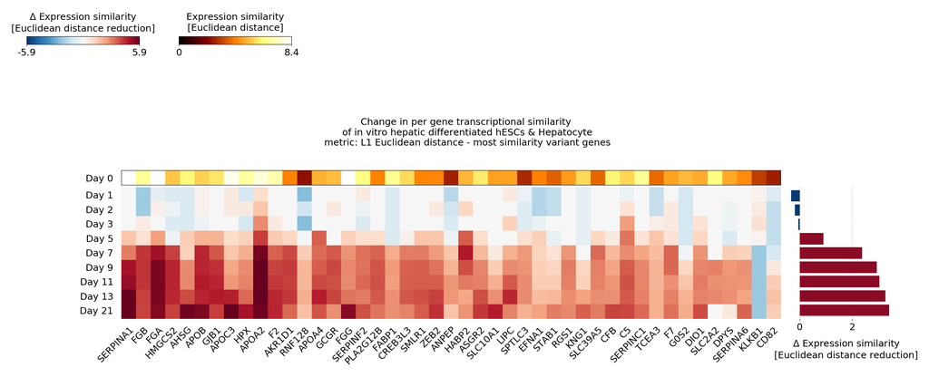

```python
hm = hep.gene_similarity_heatmap(samples = s,              # we don't need to pass metric here, 'euclid' is the default
                                 filename = None,
                                 plt_show = True)
```

By default, this function will plot the 45 most variant genes, we are however interested in the **similarity of a specifc gene list**: a collection of hepatoblast- and hepatocyte markers. We define these gene lists and generate a color legend for the two groups. Then we make a dictionary that maps the genes to the respective color. DPre's predefined **colors** can be accessed from *config.colors*:

```python
from DPre import plot_color_legend
from DPre import config
hep_bl = ['PITX2', 'KRT19', 'AFP', 'DAB2', 'FOXP4', 'SMAD3', 'FOXA1', 'HES4', 'HNF1B']
hep_cy = ['ALB', 'MXD1', 'TTR']
plot_color_legend(['Hepatoblast', 'Hepatocytes'],
                  [config.colors[11], config.colors[12]],
                  filename='hepato_markers_legend.png',
                  ncolumns = 1,
                 )
# set up the colors for the colorbar
colorbar_cols = {**dict.fromkeys(hep_bl, config.colors[11]),
                 **dict.fromkeys(hep_cy, config.colors[12])}
colorbar_cols
```

```
INFO-DPre plot_color_legend:
Color legend generated and saved at C:\Users\LOaLoA\Anaconda3\Lib\DPre\examples\example1_hsliver/hepato_markers_legend.png
```

```
{'PITX2': '#e6beff',
 'KRT19': '#e6beff',
 'AFP': '#e6beff',
 'DAB2': '#e6beff',
 'FOXP4': '#e6beff',
 'SMAD3': '#e6beff',
 'FOXA1': '#e6beff',
 'HES4': '#e6beff',
 'HNF1B': '#e6beff',
 'ALB': '#9A6324',
 'MXD1': '#9A6324',
 'TTR': '#9A6324'}
```

To check the similarity of a custom gene list, this list is passed to **custom_target_genelist**. This argument is used when we don't care about the marker genes in the reference. Instead, the passed list of genes is used for all targets. Since we will plot another gene similarity heatmap, we want to control the **heatmap_range** instead of inferring it from the data. Due to space constrains, the **summary plot** on the right is not plotted. We also pass the **pivot** argument to rotate the plot 90 degrees. This way, we can share the sample labels with the previous target_similarity heatmap. Apart from these arguments, the other inputs overlap with the previous *target_similarity_heatmap()* function:

```
=|=|=|=|=|=|=|=|====PLOT====|=|=|=|=|=|=|=|=|=
INFO-DPre gene_similarity_heatmap:
Plot: Hepatocyte & in vitro hepatic differentiated hESCs
INFO-DPre _check_args:
Both `display_genes` and `custom_target_genelist` were passed. `display_genes` will be ignored.
WARNING-DPre _check_args:
['HNF1B'] (1/12) are not detected genes in any of the targets or are not detected in the samples. These genes will not be included.
INFO-DPre _check_args:
Arguments passed. Getting data now ...

INFO-DPre plot_detec_mgs_prop:
Detection of targets (custom genelist) marker genes in samples data (in vitro hepatic differentiated hESCs):
               n marker genes  detected in samples  proportion
up Hepatocyte              11                   11         1.0
Shown are the 1 edge proportion values.

INFO-DPre _compute_similarity:
Computing similarity `euclid` of samples `in vitro hepatic differentiated hESCs` and targets: `custom genelist` ...
INFO-DPre _get_similarity:
Selecting and processing overlap data...

INFO-DPre gene_similarity_heatmap:
Drawing...
1/1 --- Hepatocyte
```

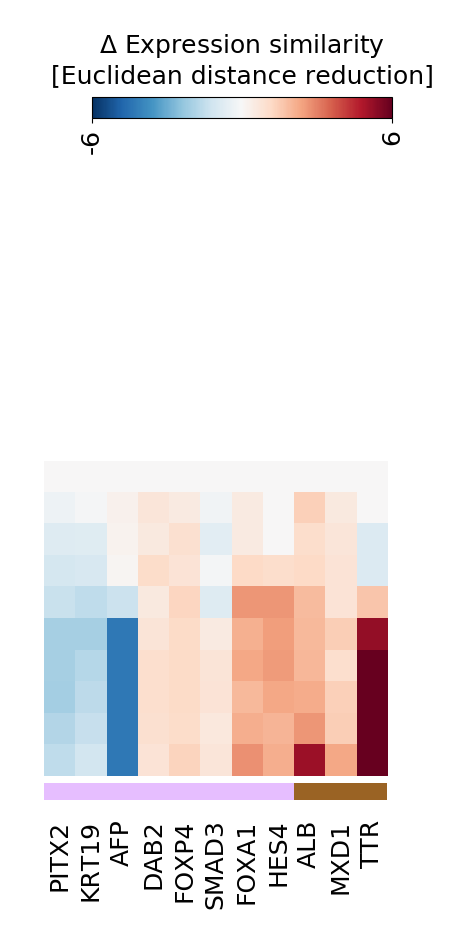

```
INFO-DPre gene_similarity_heatmap:
Plots saved at C:\Users\LOaLoA\Anaconda3\Lib\DPre\examples\example1_hsliver/hsliver_marker_genes.png
```

```python
hm = hep.gene_similarity_heatmap(samples = s,    # the sampels to explore similarity for
                                 custom_target_genelist = hep_bl+hep_cy,    # the list of genes to be visualized
                                 heatmap_range = [-6, 6],     # range heatmap values
                                 heatmap_width = .8,
                                 heatmap_height = .9,
                                 genelabels_space = .5,
                                 samplelabels_space = .1,
                                 title = None,
                                 hide_distance_bar = True,
                                 show_genes_colorbar = colorbar_cols,    # the colorbar dictionary created above
                                 pivot = True,          # rotate the plot
                                 hide_samplelabels = True,         # in the final plot, shared with the previous plot
                                 hide_sum_plot = True,     # do not plot the summerizing plot on the right
                                 filename = 'hsliver_marker_genes.png',
                                 plt_show = True,
                                )
```

The **command line interface** doesn't support custom colors. Apart from this the plot can be reproduced like so:

```python
!python ../../dpre.py -pt "human" -ts "Hepatocyte" -se "hsliver_expression.tsv" -sd "./up_genelists" -sd "./down_genelists" -c "Day00"  -sn "in vitro hepatic differentiated hESCs" gene_sim -cu "PITX2" -cu "KRT19" -cu "AFP" -cu "DAB2" -cu "FOXP4" -cu "SMAD3" -cu "FOXA1" -cu "HES4" -cu "HNF1B" -cu "ALB" -cu "MXD1" -cu "TTR" -hr -6 -hr 6 -pi -hw 0.8 -hh 0.9 -ge 0.3 -sa 0.1 -ge .5  -t "false" -hd -hsa -hs -f "hsliver_marker_genes.png"
```

Second, we want to find the 10 most similarity-increasing genes for the hepatocyte fate. Instead of passing *custom_target_genelist*, we change *display_genes* and *gene_number*. We can also use this example to remove the white space on the top of the plot. Advanced size adjustments like this are realized by passing the size constants defined in *config* (see documentation for details), in this case *HM_TOP*. This functionality is not available through the command line.

```
=|=|=|=|=|=|=|=|====PLOT====|=|=|=|=|=|=|=|=|=
INFO-DPre gene_similarity_heatmap:
Plot: Hepatocyte & in vitro hepatic differentiated hESCs
INFO-DPre _check_args:
Arguments passed. Getting data now ...
INFO-DPre _get_similarity:
Selecting and processing overlap data...

INFO-DPre gene_similarity_heatmap:
Drawing...
1/1 --- Hepatocyte
```

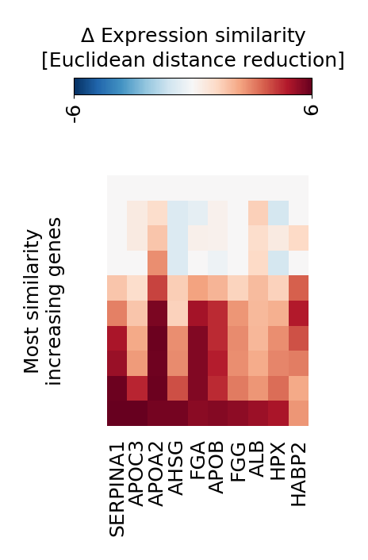

```
INFO-DPre gene_similarity_heatmap:
Plots saved at C:\Users\LOaLoA\Anaconda3\Lib\DPre\examples\example1_hsliver/hsliver_increasing_genes.svg
```

```python
hm = hep.gene_similarity_heatmap(samples = s,
                                 display_genes = 'increasing',      # the genes with peak positve similarity values
                                 gene_number = 10,        # the number of genes to extract and display
                                 heatmap_range = [-6, 6],
                                 plt_show=True,
                                 pivot = True,
                                 heatmap_width = .65,
                                 heatmap_height = .9,
                                 genelabels_space = .5,
                                 samplelabels_space = .4,
                                 title = 'Most similarity\nincreasing genes',
                                 hide_distance_bar = True,
                                 hide_samplelabels = True,
                                 hide_sum_plot = True,
                                 HM_TOP = .7,                      # the space in inches above the heatmap
                                 filename = 'hsliver_increasing_genes.svg',
                                )
```

```python
!python ../../dpre.py -pt "human" -ts "Hepatocyte" -se "hsliver_expression.tsv" -sd "./up_genelists" -sd "./down_genelists" -c "Day00"  -sn "in vitro hepatic differentiated hESCs" gene_sim -gn 10 -di "increasing" -hr -6 -hr 6 -pi -hw 0.8 -hh 0.9 -ge 0.3 -sa 0.1 -ge .5  -t "Most similarity\nincreasing genes" -hd -hs -hsa -hs -f "hsliver_marker_genes.png"
```

Done. We now have an idea about the genes behind the differentiation bias towards hepatocytes. This is how Figure 1C was generated with DPre.